# Practical_Lab10_Assignment

## Practical Lab 10 - Vanilla CNN and Fine-Tune VGG16 - for Dogs and Cats Classification 🐶 🐱

```python
from tensorflow import keras
import tensorflow as tf
from tensorflow.keras import layers
import pathlib
from tensorflow.keras.utils import image_dataset_from_directory
import matplotlib.pyplot as plt
```

```python
data_folder = pathlib.Path('C:/Users/deept/Dee-CSCN8010_ClassNoteBook/CSCN8010---Class-NoteBook/data/kaggle_dogs_vs_cats_small')
```

```python
train_dataset = image_dataset_from_directory(
    data_folder / "train",
    image_size=(180, 180),
    batch_size=32)
validation_dataset = image_dataset_from_directory(
    data_folder / "validation",
    image_size=(180, 180),
    batch_size=32)
test_dataset = image_dataset_from_directory(
    data_folder / "test",
    image_size=(180, 180),
    batch_size=32)
```

```
Found 2000 files belonging to 2 classes.
Found 1000 files belonging to 2 classes.
Found 2000 files belonging to 2 classes.
```

### Exploratory Data Analysis

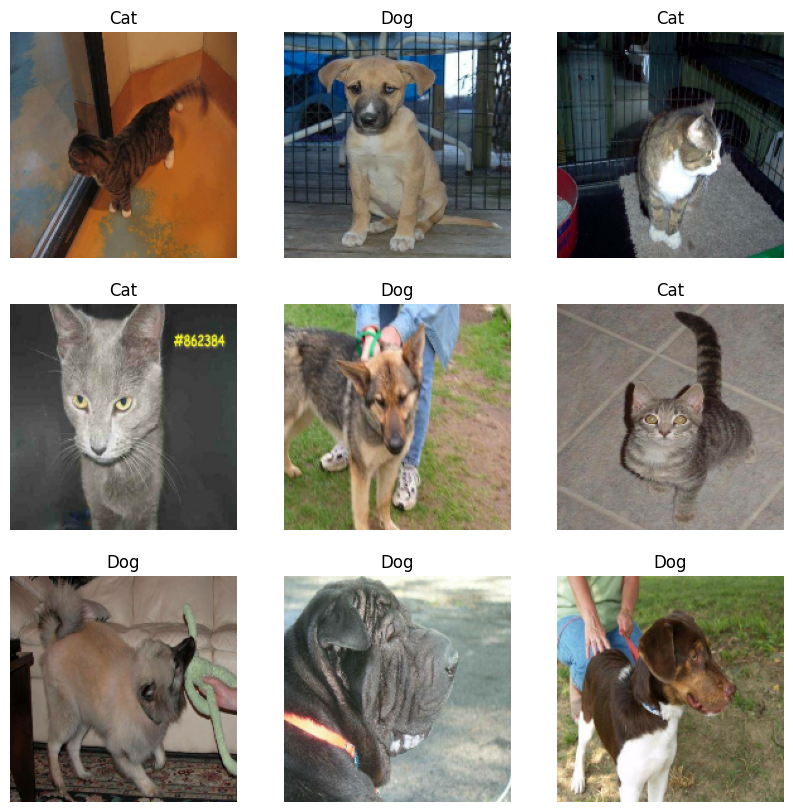

```python
# Visualize sample images
plt.figure(figsize=(10, 10))
for images, labels in train_dataset.take(1):
    for i in range(9):
        ax = plt.subplot(3, 3, i + 1)
        plt.imshow(images[i].numpy().astype("uint8"))
        plt.title('Dog' if labels[i] == 1 else 'Cat')
        plt.axis("off")
plt.show()
```

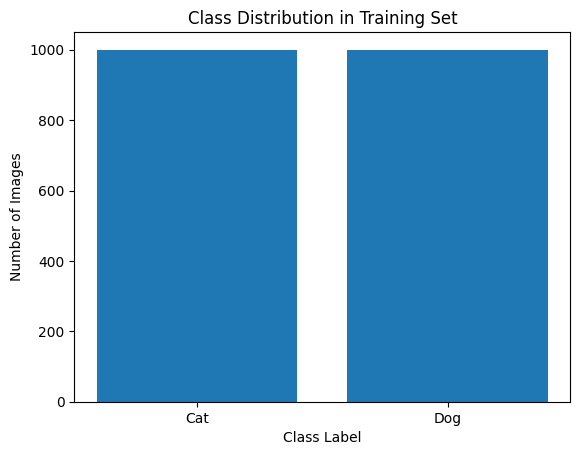

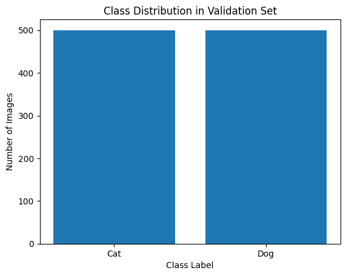

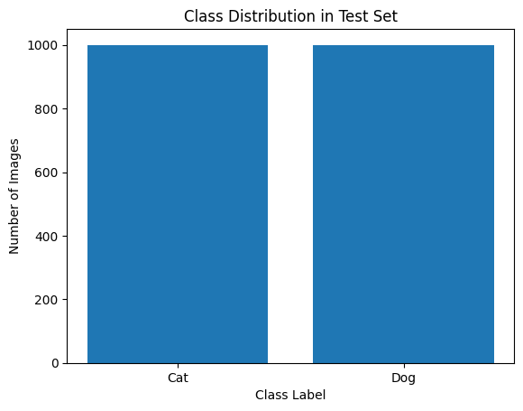

```python
# Class Distribution
def plot_class_distribution(dataset, dataset_name):
    class_counts = {}
    for images, labels in dataset:
        for label in labels:
            class_counts[label.numpy()] = class_counts.get(label.numpy(), 0) + 1

    plt.bar(class_counts.keys(), class_counts.values())
    plt.xlabel('Class Label')
    plt.ylabel('Number of Images')
    plt.title(f'Class Distribution in {dataset_name}')
    plt.xticks(range(len(class_counts)), ['Cat', 'Dog'])
    plt.show()

plot_class_distribution(train_dataset, 'Training Set')
plot_class_distribution(validation_dataset, 'Validation Set')
plot_class_distribution(test_dataset, 'Test Set')
```

Insights: The training set contains 2000 images, the validation set contains 1000 images, and the test set also contains 2000 images. This is a relatively small dataset for a deep learning task, but it could be enough for a simple binary classification problem like distinguishing between dogs and cats.

### CNN and Data Augmentation

```python
inputs = keras.Input(shape=(180, 180, 3))
x = layers.Rescaling(1./255)(inputs)
x = layers.Conv2D(filters=32, kernel_size=3, activation="relu")(x)
x = layers.MaxPooling2D(pool_size=2)(x)
x = layers.Conv2D(filters=64, kernel_size=3, activation="relu")(x)
x = layers.MaxPooling2D(pool_size=2)(x)
x = layers.Conv2D(filters=128, kernel_size=3, activation="relu")(x)
x = layers.MaxPooling2D(pool_size=2)(x)
x = layers.Conv2D(filters=256, kernel_size=3, activation="relu")(x)
x = layers.MaxPooling2D(pool_size=2)(x)
x = layers.Conv2D(filters=256, kernel_size=3, activation="relu")(x)
x = layers.Flatten()(x)
outputs = layers.Dense(1, activation="sigmoid")(x)
model = keras.Model(inputs=inputs, outputs=outputs)
```

```python
model.summary()
```

```
Model: "model"
_________________________________________________________________
 Layer (type)                Output Shape              Param #
=================================================================
 input_1 (InputLayer)        [(None, 180, 180, 3)]     0

 rescaling_1 (Rescaling)     (None, 180, 180, 3)       0

 conv2d_3 (Conv2D)           (None, 178, 178, 32)      896

 max_pooling2d_3 (MaxPooling  (None, 89, 89, 32)       0
 2D)

 conv2d_4 (Conv2D)           (None, 87, 87, 64)        18496

 max_pooling2d_4 (MaxPooling  (None, 43, 43, 64)       0
 2D)

 conv2d_5 (Conv2D)           (None, 41, 41, 128)       73856

 max_pooling2d_5 (MaxPooling  (None, 20, 20, 128)      0
 2D)

 conv2d_6 (Conv2D)           (None, 18, 18, 256)       295168

 max_pooling2d_6 (MaxPooling  (None, 9, 9, 256)        0
 2D)

 conv2d_7 (Conv2D)           (None, 7, 7, 256)         590080

 flatten_1 (Flatten)         (None, 12544)             0

 dense_2 (Dense)             (None, 1)                 12545

=================================================================
Total params: 991,041
Trainable params: 991,041
Non-trainable params: 0
_________________________________________________________________
```

```python
model.compile(loss="binary_crossentropy",
              optimizer="rmsprop",
              metrics=["accuracy"])
```

```python
callbacks = [
    keras.callbacks.ModelCheckpoint(
        filepath="./models/convnet_from_scratch.keras",
        save_best_only=True,
        monitor="val_loss")
]
history = model.fit(
    train_dataset,
    epochs=30,
    validation_data=validation_dataset,
    callbacks=callbacks)
```

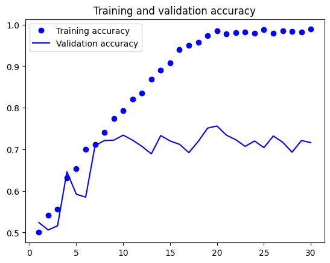

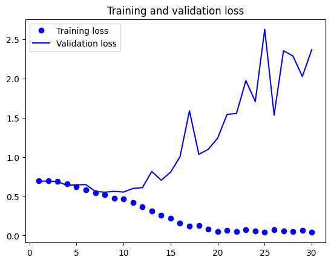

```python
accuracy = history.history["accuracy"]
val_accuracy = history.history["val_accuracy"]
loss = history.history["loss"]
val_loss = history.history["val_loss"]
epochs = range(1, len(accuracy) + 1)
plt.plot(epochs, accuracy, "bo", label="Training accuracy")
plt.plot(epochs, val_accuracy, "b", label="Validation accuracy")
plt.title("Training and validation accuracy")
plt.legend()
plt.figure()
plt.plot(epochs, loss, "bo", label="Training loss")
plt.plot(epochs, val_loss, "b", label="Validation loss")
plt.title("Training and validation loss")
plt.legend()
plt.show()
```

```python
test_model = keras.models.load_model("./models/convnet_from_scratch.keras")
test_loss, test_acc = test_model.evaluate(test_dataset)
print(f"Test accuracy: {test_acc:.3f}")
```

```
Test accuracy: 0.705
```

```python
data_augmentation = keras.Sequential(
    [
        layers.RandomFlip("horizontal"),
        layers.RandomRotation(0.1),
        layers.RandomZoom(0.2),
    ]
)
```

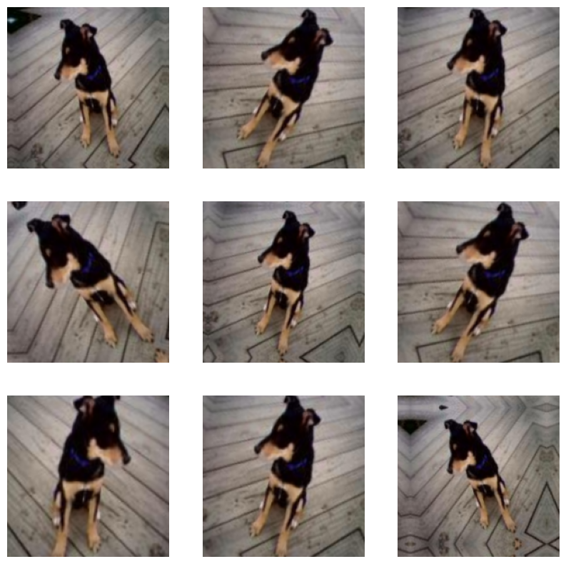

```python
plt.figure(figsize=(10, 10))
for images, _ in train_dataset.take(1):
    for i in range(9):
        augmented_images = data_augmentation(images)
        ax = plt.subplot(3, 3, i + 1)
        plt.imshow(augmented_images[0].numpy().astype("uint8"))
        plt.axis("off")
```

### Fine Tuning VGG16

```python
conv_base = keras.applications.vgg16.VGG16(
    weights="imagenet",
    include_top=False,
    input_shape=(180, 180, 3))

conv_base.summary()
```

```
Model: "vgg16"
_________________________________________________________________
 Layer (type)                Output Shape              Param #
=================================================================
 input_5 (InputLayer)        [(None, 180, 180, 3)]     0

 block1_conv1 (Conv2D)       (None, 180, 180, 64)      1792

 block1_conv2 (Conv2D)       (None, 180, 180, 64)      36928

 block1_pool (MaxPooling2D)  (None, 90, 90, 64)        0

 block2_conv1 (Conv2D)       (None, 90, 90, 128)       73856

 block2_conv2 (Conv2D)       (None, 90, 90, 128)       147584

 block2_pool (MaxPooling2D)  (None, 45, 45, 128)       0

 block3_conv1 (Conv2D)       (None, 45, 45, 256)       295168

 block3_conv2 (Conv2D)       (None, 45, 45, 256)       590080

 block3_conv3 (Conv2D)       (None, 45, 45, 256)       590080

 block3_pool (MaxPooling2D)  (None, 22, 22, 256)       0

 block4_conv1 (Conv2D)       (None, 22, 22, 512)       1180160

 block4_conv2 (Conv2D)       (None, 22, 22, 512)       2359808

 block4_conv3 (Conv2D)       (None, 22, 22, 512)       2359808

 block4_pool (MaxPooling2D)  (None, 11, 11, 512)       0

 block5_conv1 (Conv2D)       (None, 11, 11, 512)       2359808

 block5_conv2 (Conv2D)       (None, 11, 11, 512)       2359808

 block5_conv3 (Conv2D)       (None, 11, 11, 512)       2359808

 block5_pool (MaxPooling2D)  (None, 5, 5, 512)         0

=================================================================
Total params: 14,714,688
Trainable params: 14,714,688
Non-trainable params: 0
_________________________________________________________________
```

```python
import numpy as np

def get_features_and_labels(dataset):
    all_features = []
    all_labels = []
    for images, labels in dataset:
        preprocessed_images = keras.applications.vgg16.preprocess_input(images)
        features = conv_base.predict(preprocessed_images)
        all_features.append(features)
        all_labels.append(labels)
    return np.concatenate(all_features), np.concatenate(all_labels)

train_features, train_labels =  get_features_and_labels(train_dataset)
val_features, val_labels =  get_features_and_labels(validation_dataset)
test_features, test_labels =  get_features_and_labels(test_dataset)
```

```python
# Freeze layers except for the last four
conv_base.trainable = True
for layer in conv_base.layers[:-4]:
    layer.trainable = False
```

```python
# Define the model architecture
inputs = keras.Input(shape=(180, 180, 3))
x = layers.Rescaling(1./255)(inputs)
x = conv_base(x, training=False)  # Use VGG16 as a layer
x = layers.Flatten()(x)
outputs = layers.Dense(1, activation="sigmoid")(x)
model = keras.Model(inputs=inputs, outputs=outputs)
```

```python
# Compile the model for fine-tuning
model.compile(loss="binary_crossentropy",
              optimizer=keras.optimizers.RMSprop(learning_rate=1e-5),
              metrics=["accuracy"])
```

```python
# Define callbacks
callbacks = [
    keras.callbacks.ModelCheckpoint(
        filepath="./models/fine_tuning.keras",
        save_best_only=True,
        monitor="val_loss")
]
```

```python
# Train the model
history = model.fit(
    train_dataset,
    epochs=30,
    validation_data=validation_dataset,
    callbacks=callbacks)
```

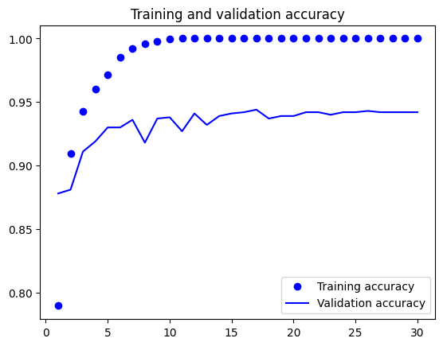

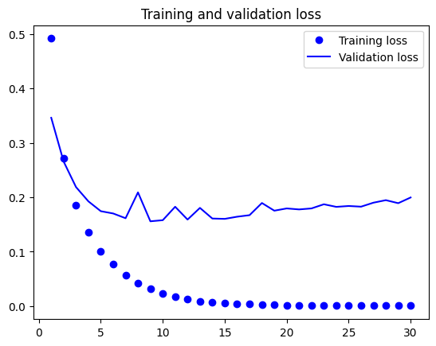

```python
# Plot training and validation performance
acc = history.history["accuracy"]
val_acc = history.history["val_accuracy"]
loss = history.history["loss"]
val_loss = history.history["val_loss"]
epochs = range(1, len(acc) + 1)

plt.plot(epochs, acc, "bo", label="Training accuracy")
plt.plot(epochs, val_acc, "b", label="Validation accuracy")
plt.title("Training and validation accuracy")
plt.legend()
plt.figure()
plt.plot(epochs, loss, "bo", label="Training loss")
plt.plot(epochs, val_loss, "b", label="Validation loss")
plt.title("Training and validation loss")
plt.legend()
plt.show()
```

```python
# Evaluate the model on the test set
model = keras.models.load_model("./models/fine_tuning.keras")
test_loss, test_acc = model.evaluate(test_dataset)
print(f"Test accuracy: {test_acc:.3f}")
```

```
Test accuracy: 0.928
```

```python
# Load the best version of the CNN trained from scratch
cnn_model = keras.models.load_model("./models/convnet_from_scratch.keras")

# Load the best version of the fine-tuned VGG16 model
vgg16_model = keras.models.load_model("./models/fine_tuning.keras")

# Evaluate the performance of each model on the test dataset
cnn_test_loss, cnn_test_accuracy = cnn_model.evaluate(test_dataset)
vgg16_test_loss, vgg16_test_accuracy = vgg16_model.evaluate(test_dataset)

print("CNN Test Accuracy:", cnn_test_accuracy)
print("VGG16 Test Accuracy:", vgg16_test_accuracy)
```

```
CNN Test Accuracy: 0.7049999833106995
VGG16 Test Accuracy: 0.9279999732971191
```

Insights: The CNN model has a test accuracy of approximately 70.5%, while the fine-tuned VGG16 model has a significantly higher test accuracy of approximately 92.8%.

```python
from sklearn.metrics import accuracy_score, confusion_matrix, classification_report, precision_recall_curve
import numpy as np


# Function to evaluate model and generate performance metrics
def evaluate_model(model, test_dataset):
    y_true = []
    y_pred = []
    for images, labels in test_dataset:
        y_true.extend(labels.numpy())
        y_pred.extend(np.round(model.predict(images)))

    # Calculate accuracy
    acc = accuracy_score(y_true, y_pred)

    # Calculate confusion matrix
    cm = confusion_matrix(y_true, y_pred)

    # Calculate precision, recall, F1-score
    report = classification_report(y_true, y_pred, target_names=['Cat', 'Dog'])

    # Calculate precision-recall curve
    precision, recall, _ = precision_recall_curve(y_true, y_pred)

    return acc, cm, report, precision, recall
```

```python
# Evaluate CNN model
cnn_acc, cnn_cm, cnn_report, cnn_precision, cnn_recall = evaluate_model(cnn_model, test_dataset)

# Print confusion matrix
print("\nConfusion Matrix (CNN):\n", cnn_cm)

# Print precision, recall, F1-score
print("\nClassification Report (CNN):\n", cnn_report)
```

```
Confusion Matrix (CNN):
 [[732 268]
 [322 678]]

Classification Report (CNN):
               precision    recall  f1-score   support

         Cat       0.69      0.73      0.71      1000
         Dog       0.72      0.68      0.70      1000

    accuracy                           0.70      2000
   macro avg       0.71      0.71      0.70      2000
weighted avg       0.71      0.70      0.70      2000
```

Confusion Matrix:

The confusion matrix is a 2x2 matrix that tabulates the counts of true positive (TP), false positive (FP), true negative (TN), and false negative (FN) predictions made by the model.

In this case:

Precision: Precision measures the accuracy of positive predictions made by the model. It is calculated as TP / (TP + FP).

Precision for Cat: 0.69 - Out of all the images predicted as cats, 69% were actually cats.

Precision for Dog: 0.72 - Out of all the images predicted as dogs, 72% were actually dogs.

Recall: Recall, or Sensitivity, measures the ability of the model to correctly identify the true positives. It is calculated as TP / (TP + FN).

Recall for Cat: 0.73 - The model correctly identified 73% of all the actual cat images.

Recall for Dog: 0.68 - The model correctly identified 68% of all the actual dog images.

F1-score: The F1-score is the harmonic mean of precision and recall. It provides a balance between precision and recall.

F1-score for Cat: 0.71

F1-score for Dog: 0.70

Accuracy: The overall accuracy of the model, calculated as the ratio of correct predictions to the total number of predictions.

Accuracy: 0.70 - The model achieved an accuracy of 70% on the test dataset.

```python
# Evaluate VGG16 model
vgg16_acc, vgg16_cm, vgg16_report, vgg16_precision, vgg16_recall = evaluate_model(vgg16_model, test_dataset)

# Print confusion matrix
print("\nConfusion Matrix (VGG16):\n", vgg16_cm)

# Print precision, recall, F1-score
print("\nClassification Report (VGG16):\n", vgg16_report)
```

```
Confusion Matrix (VGG16):
 [[915  85]
 [ 59 941]]

Classification Report (VGG16):
               precision    recall  f1-score   support

         Cat       0.94      0.92      0.93      1000
         Dog       0.92      0.94      0.93      1000

    accuracy                           0.93      2000
   macro avg       0.93      0.93      0.93      2000
weighted avg       0.93      0.93      0.93      2000
```

Confusion Matrix:

True Positives (TP): 941 - The model correctly predicted 941 images as dogs (actual dogs).

False Positives (FP): 85 - The model incorrectly predicted 85 images as dogs when they were actually cats.

False Negatives (FN): 59 - The model incorrectly predicted 59 images as cats when they were actually dogs.

True Negatives (TN): 915 - The model correctly predicted 915 images as cats (actual cats).

Classification Report:

Precision: Precision measures the accuracy of positive predictions made by the model. It indicates how many of the predicted positive instances are actually positive.

Precision for Cat: 0.94 - 94% of the images predicted as cats were actually cats.

Precision for Dog: 0.92 - 92% of the images predicted as dogs were actually dogs.

Recall: Recall, or Sensitivity, measures the ability of the model to correctly identify the true positives. It indicates how many of the actual positive instances were correctly predicted by the model.

Recall for Cat: 0.92 - The model correctly identified 92% of all the actual cat images.

Recall for Dog: 0.94 - The model correctly identified 94% of all the actual dog images.

F1-score: The F1-score is the harmonic mean of precision and recall. It provides a balance between precision and recall.

F1-score for Cat: 0.93

F1-score for Dog: 0.93

Accuracy: The overall accuracy of the model, calculated as the ratio of correct predictions to the total number of predictions.

Accuracy: 0.93 - The VGG16 model achieved an accuracy of 93% on the test dataset.

Insights:

The VGG16 model demonstrates superior performance compared to the CNN model, with higher precision, recall, F1-score, and accuracy for both classes (Cat and Dog).

The VGG16 model has significantly fewer false positives and false negatives compared to the CNN model, indicating its ability to better distinguish between cats and dogs.

Overall, the VGG16 model shows robust performance in image classification tasks, showcasing its effectiveness in feature extraction and classification.

```python
import numpy as np
import matplotlib.pyplot as plt
from sklearn.metrics import confusion_matrix, classification_report, precision_recall_curve
import seaborn as sns

# Load the best version of the VGG16 model
vgg16_model = keras.models.load_model("./models/fine_tuning.keras")
```

### Confusion Metric

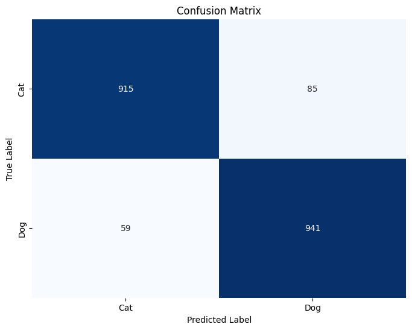

```python
# Function to plot confusion matrix
def plot_confusion_matrix(model, test_dataset):
    true_labels = []
    predicted_labels = []

    for images, labels in test_dataset:
        predictions = np.round(model.predict(images)).flatten()
        true_labels.extend(labels.numpy())
        predicted_labels.extend(predictions)

    # Generate confusion matrix
    cm = confusion_matrix(true_labels, predicted_labels)

    # Plot confusion matrix
    plt.figure(figsize=(8, 6))
    sns.heatmap(cm, annot=True, fmt="d", cmap="Blues", cbar=False,
                xticklabels=['Cat', 'Dog'], yticklabels=['Cat', 'Dog'])
    plt.xlabel('Predicted Label')
    plt.ylabel('True Label')
    plt.title('Confusion Matrix')
    plt.show()

# Plot confusion matrix for VGG16 model
plot_confusion_matrix(vgg16_model, test_dataset)
```

### Precision-Recall Curve

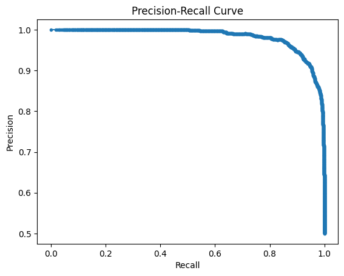

```python
# Function to plot precision-recall curve
def plot_precision_recall_curve(model, test_dataset):
    true_labels = []
    predicted_probs = []

    for images, labels in test_dataset:
        true_labels.extend(labels.numpy())
        predicted_probs.extend(model.predict(images).flatten())

    # Calculate precision-recall curve
    precision, recall, _ = precision_recall_curve(true_labels, predicted_probs)

    # Plot precision-recall curve
    plt.plot(recall, precision, marker='.')
    plt.xlabel('Recall')
    plt.ylabel('Precision')
    plt.title('Precision-Recall Curve')
    plt.show()

# Plot precision-recall curve for VGG16 model
plot_precision_recall_curve(vgg16_model, test_dataset)
```

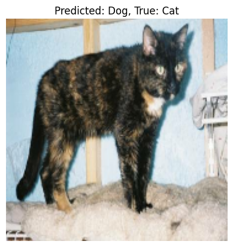

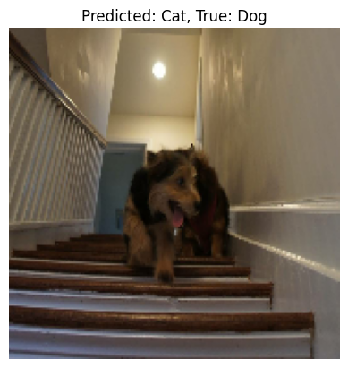

[figure not shown]

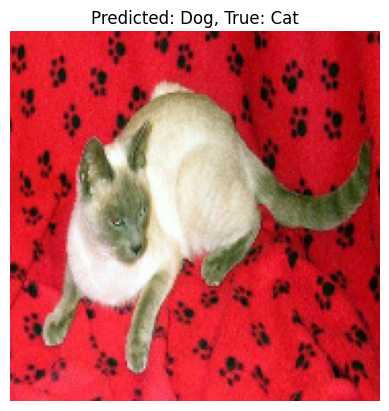

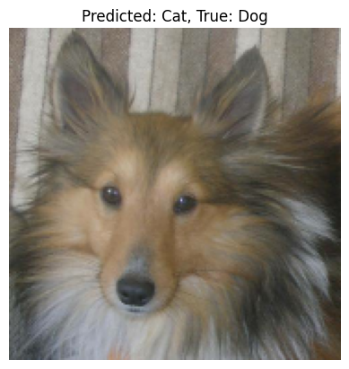

```python
# Function to explore specific examples where the model failed
def explore_failed_predictions(model, test_dataset):
    incorrect_predictions = []

    for images, labels in test_dataset:
        predictions = np.round(model.predict(images)).flatten()
        for i in range(len(predictions)):
            if predictions[i] != labels[i]:
                incorrect_predictions.append((images[i], predictions[i], labels[i]))

    return incorrect_predictions

# Explore failed predictions for VGG16 model
failed_predictions_vgg16 = explore_failed_predictions(vgg16_model, test_dataset)

# Display the first few examples of failed predictions
for i in range(min(5, len(failed_predictions_vgg16))):
    image, predicted_label, true_label = failed_predictions_vgg16[i]
    plt.imshow(image.numpy().astype("uint8"))
    plt.title(f'Predicted: {"Dog" if predicted_label == 1 else "Cat"}, True: {"Dog" if true_label == 1 else "Cat"}')
    plt.axis('off')
    plt.show()
```

## CONCLUSION

The analysis shows that the VGG16 model performs better than the CNN model, as indicated by higher accuracy, precision, recall, and F1-scores for both classes (Cat and Dog) in the classification report. However, it's essential to understand that even though the VGG16 model outperforms the CNN model overall, there can still be instances where it misclassifies images.

The models may fail in various scenarios, Ambiguity in Images: Some images may contain elements that make it difficult for the model to accurately classify them. For example, if a cat image contains elements that are more commonly associated with dogs (such as a large body or a long snout), the model might incorrectly predict it as a dog.

Variability in Data: The dataset may contain images with significant variability within each class, making it challenging for the model to learn representative features. For instance, different breeds of dogs or cats may have diverse appearances, leading to misclassifications.

Noise or Artifacts: Images in the dataset may contain noise, artifacts, or irrelevant features that confuse the model and lead to incorrect predictions. These could include image distortions, background clutter, or occlusions.

Similarity Between Classes: Cats and dogs share some visual characteristics, such as fur texture or body shape, which can make it challenging for the model to distinguish between them, especially in certain poses or lighting conditions.

Model Complexity: While VGG16 is a powerful model architecture, it may still struggle with certain images due to its fixed structure and limited receptive field.

Data Imbalance: If the dataset contains an unequal number of cat and dog images, the model may be biased towards the majority class, leading to poorer performance on the minority class.